# Week 7 - Visualizing Text Data Using Word Clouds

#### Problem 4.3 - Selecting a Color Palette

In sequential palettes, sometimes there is an undesirably large contrast between the lightest and darkest colors. You can see this effect when plotting a word cloud for allTweets with parameter colors=brewer.pal(9, “Blues”), which returns a sequential blue palette with 9 colors.

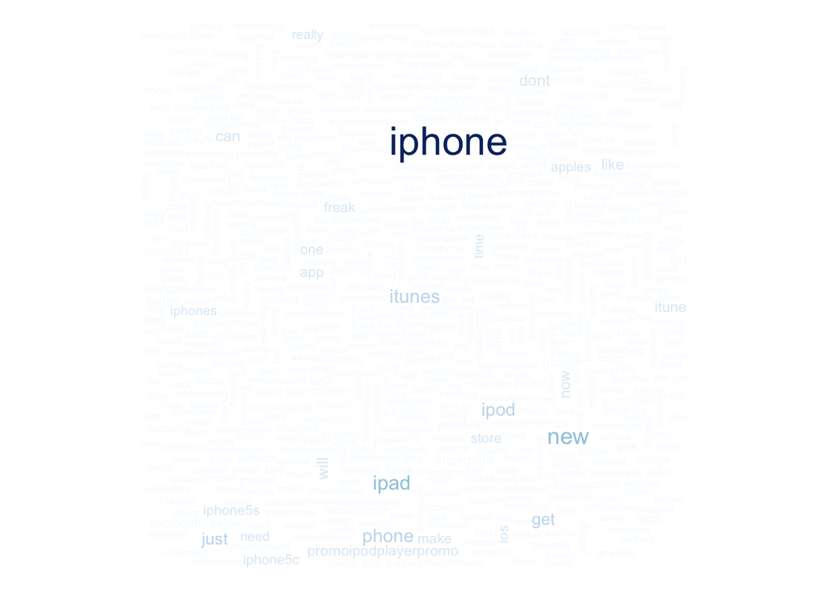

```r
wordcloud(colnames(allTweets),colSums(allTweets), scale=c(2, 0.5),colors=brewer.pal(9, "Blues"))
```

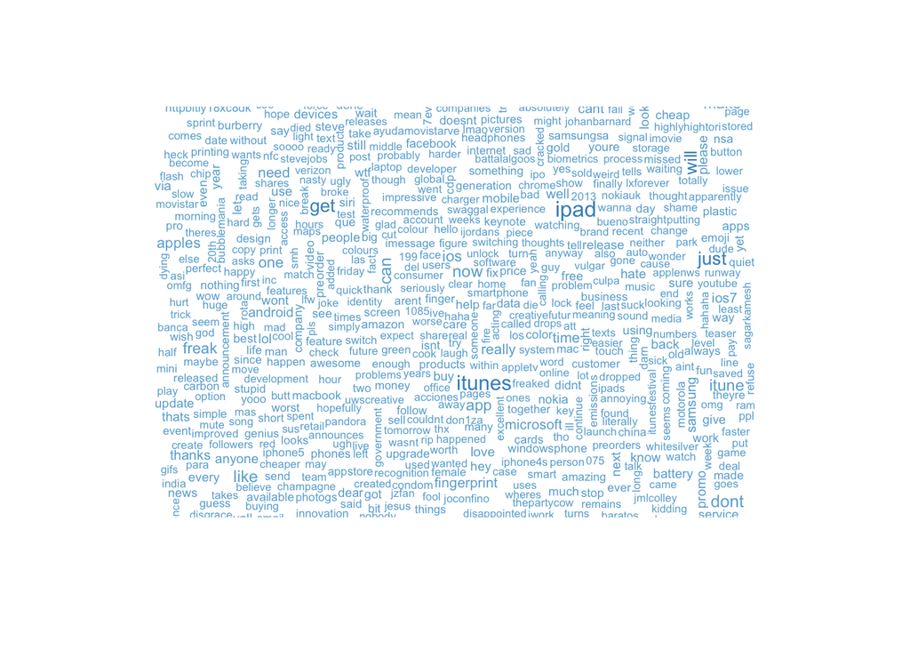

```r
wordcloud(colnames(allTweets),colSums(allTweets), scale=c(2, 0.5),colors=brewer.pal(9, "Blues")[c(5, 6, 7, 8, 9)])
```

Which of the following commands addresses this issue by removing the first 4 elements of the 9-color palette of blue colors? Select all that apply.

- brewer.pal(9, “Blues”)[c(-5, -6, -7, -8, -9)]
- **brewer.pal(9, “Blues”)[c(-1, -2, -3, -4)]**
- brewer.pal(9, “Blues”)[c(1, 2, 3, 4)]
- **brewer.pal(9, “Blues”)[c(5, 6, 7, 8, 9)]**